# d589_hfianalysis

Vidal Mendoza Tinoco (76236256)

2025-04-13

```r
# load and view data
load("bc_bear_occurrences.Rda")
load("BC_Covariates.Rda")
summary(DATA)
```

```
##            Length Class           Mode
## Window      1     SpatialPolygons S4
## Elevation  10     im              list
## Forest     10     im              list
## HFI        10     im              list
## Dist_Water 10     im              list
```

### set general ppp object

```r
# extract location columns
bears_loc <- occ_data[, c("decimalLongitude", "decimalLatitude", "month", "year")]
bears_loc_filtered <- subset(bears_loc, year %in% c(2020, 2021, 2022, 2023, 2024))

# create sf object
bears_sf <- st_as_sf(
  bears_loc_filtered,
  coords = c("decimalLongitude", "decimalLatitude"),
  crs = 4326  # WGS84 (longitude/latitude)
)

# BC Albers projection
bears_sf_proj <- st_transform(bears_sf, crs = 3005)

# extract x, y coordinates
coords <- st_coordinates(bears_sf_proj)

# extract BC window
window_sf <- st_as_sf(DATA$Window) # convert SpatialPolygons to Simple Features (sf)
window_proj <- st_transform(window_sf, crs = 3005) # ensure same CRS
window <- as.owin(window_proj) # convert to owin using sf object

# create ppp object
bears_ppp <- ppp(
  x = coords[,1],
  y = coords[,2],
  window = window
)
```

### Seasonal distributions

```r
# Define the seasons and corresponding colors
seasons <- list(
  winter = c(12, 1, 2),
  spring = c(3, 4, 5),
  summer = c(6, 7, 8),
  autumn = c(9, 10, 11)
)

# Create an empty list to store the ppp objects for each season
ppp_list <- list()

# Create an empty list to store the filtered data for each season
bears_sf_list <- list()

# Loop over seasons
for (i in 1:length(seasons)) {

  # Filter for each season
  season_name <- names(seasons)[i]
  season_months <- seasons[[i]]

  # Filter bears_loc_filtered by the season's months
  bears_loc_season <- bears_loc_filtered[bears_loc_filtered$month %in% season_months, ]

  # Print the number of observations for this season
  cat(season_name, ": ", nrow(bears_loc_season), " observations\n", sep="")

  # Create sf object for the filtered season
  bears_sf_season <- st_as_sf(
    bears_loc_season,
    coords = c("decimalLongitude", "decimalLatitude"),
    crs = 4326  # WGS84 (longitude/latitude)
  )

  # Transform to BC Albers projection
  bears_sf_season_proj <- st_transform(bears_sf_season, crs = 3005)

  # Store sf object in the list
  bears_sf_list[[season_name]] <- bears_sf_season_proj

  # Extract x, y coordinates
  coords <- st_coordinates(bears_sf_season_proj)

  # Create ppp object for each season
  suppressWarnings(
    bears_ppp_season <- ppp(
      x = coords[, 1],
      y = coords[, 2],
      window = window
    )
  )

  # Store ppp object in the list
  ppp_list[[season_name]] <- bears_ppp_season
}
```

```
## winter: 76 observations
## spring: 808 observations
## summer: 1862 observations
## autumn: 841 observations
```

### HFI Analyisis

```r
elev <- DATA$Elevation
cover <- DATA$Forest
dist_water <- DATA$Dist_Water
hfi <- DATA$HFI
```

```r
hfi_matrix <- as.matrix(hfi)
media_hfi <- mean(as.vector(hfi_matrix), na.rm = TRUE)
cat("Mean HFI (without NA):", media_hfi, "\n")
```

```
## Mean HFI (without NA): 0.09459461
```

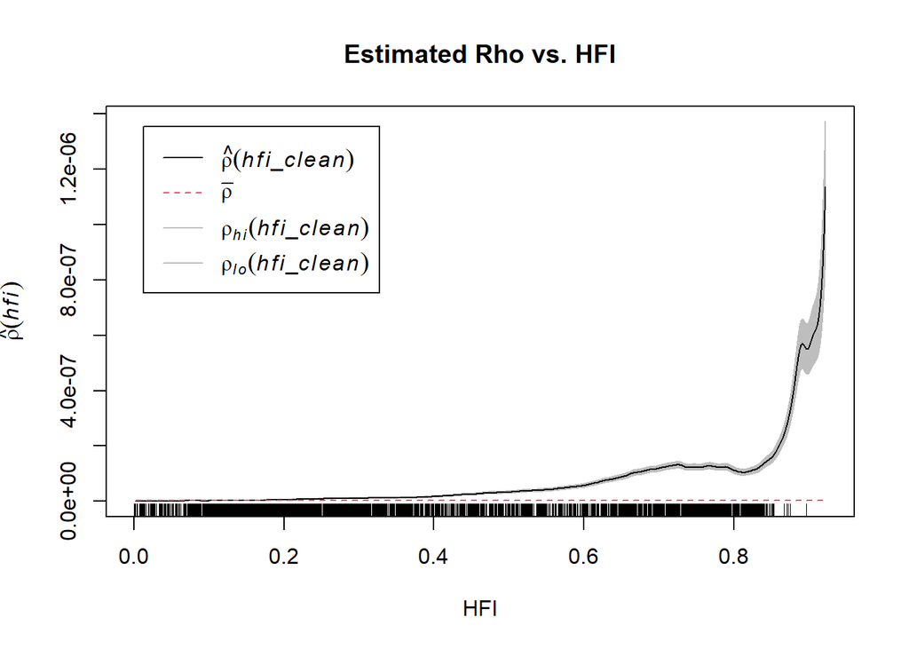

```r
# Impute NA values in HFI using the mean
hfi_clean <- eval.im( ifelse(is.na(hfi), media_hfi, hfi) )

# HFI range
hfi_vals <- as.vector(as.matrix(hfi_clean))
hfi_rng  <- range(hfi_vals, na.rm = TRUE)

# rho(hfi)
rho <- rhohat(bears_ppp, hfi_clean)

# plot
plot(rho,
     xlim = hfi_rng,
     xlab = "HFI",
     ylab = expression(hat(rho)(hfi)),
     main = "Estimated Rho vs. HFI")
```

**Interpretation:** The estimate of rho(hfi) shows that in areas with very low human footprint, bear density is at or below average, increasing gradually at intermediate HFI values (0.1 and 0.6) and, starting at HFI = 0.7 - 0.8, experiencing a pronounced jump above the average, indicating much higher bear concentrations in those few places with high human intervention. However, at this extreme the uncertainty band widens considerably, reflecting less data and greater variability in the estimate.

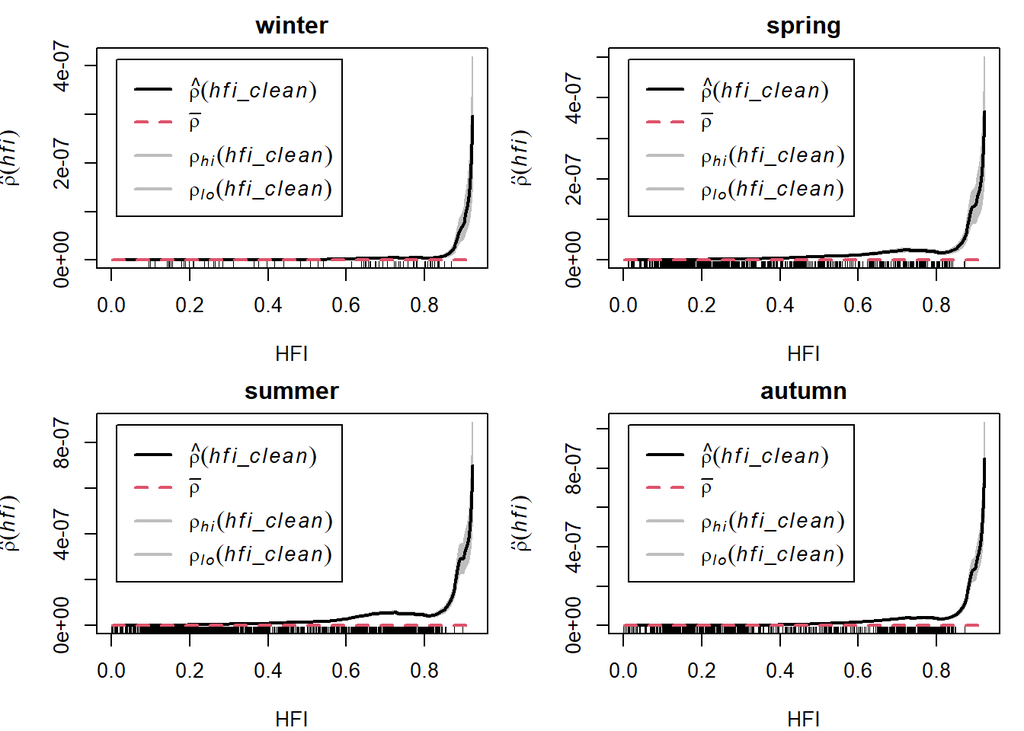

```r
# Plot rho(hfi) for each season on the same HFI scale
par(mfrow = c(2, 2), mar = c(4, 4, 2, 1))
for (season_name in names(ppp_list)) {
  rho_season <- rhohat(ppp_list[[season_name]], hfi_clean)
  plot(rho_season,
       xlim  = hfi_rng,
       xlab  = "HFI",
       ylab  = expression(hat(rho)(hfi)),
       main  = season_name,
       lwd   = 2)
}
```

### EDA

```r
# HFI for bears locations

# im object to RasterLayer
im2raster <- function(im_obj) {
  # iamge to matrix
  m <- as.matrix(im_obj)
  # create raster object
  r <- raster(m)
  # range and extension
  ext <- c(im_obj$xrange[1] - im_obj$xstep/2,
           im_obj$xrange[2] + im_obj$xstep/2,
           im_obj$yrange[1] - im_obj$ystep/2,
           im_obj$yrange[2] + im_obj$ystep/2)
  extent(r) <- ext
  return(r)
}

# hfi to RasterLayer
hfi_raster <- im2raster(hfi)

# HFI in bear locations
bears_sf_proj$hfi_value <- extract(hfi_raster, bears_sf_proj)

summary(bears_sf_proj$hfi_value)
```

```
##    Min. 1st Qu.  Median    Mean 3rd Qu.    Max.    NA's
##  0.0000  0.0000  0.0168  0.0603  0.1009  0.5287    1516
```

**Interpretation:** The results suggest that most bear occurrences are found in areas with very low human footprints (values close to 0), which aligns with the expectation that bears are sensitive to human impact and tend to inhabit remote or undisturbed areas. The distribution is skewed to the right, indicating the presence of a few points in areas with higher HFIs that slightly elevate the mean, but do not change the fact that, overall, bears are predominantly detected in habitats with low human interference.

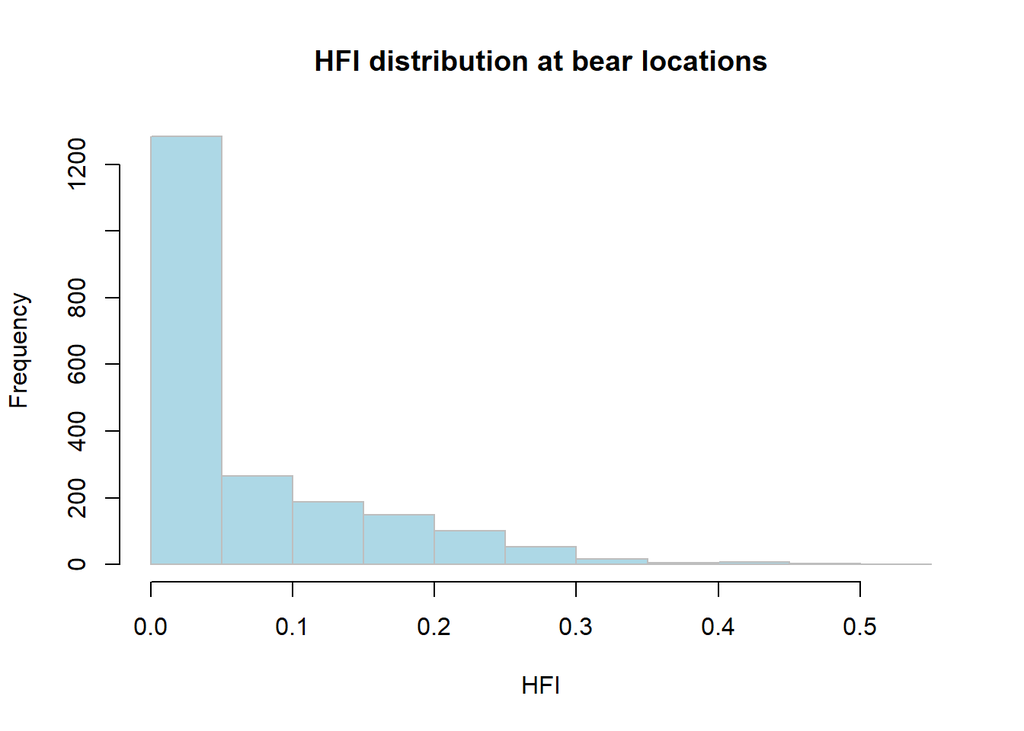

```r
hist(bears_sf_proj$hfi_value,
     main = "HFI distribution at bear locations",
     xlab = "HFI",
     col = "lightblue", border = "grey")
```

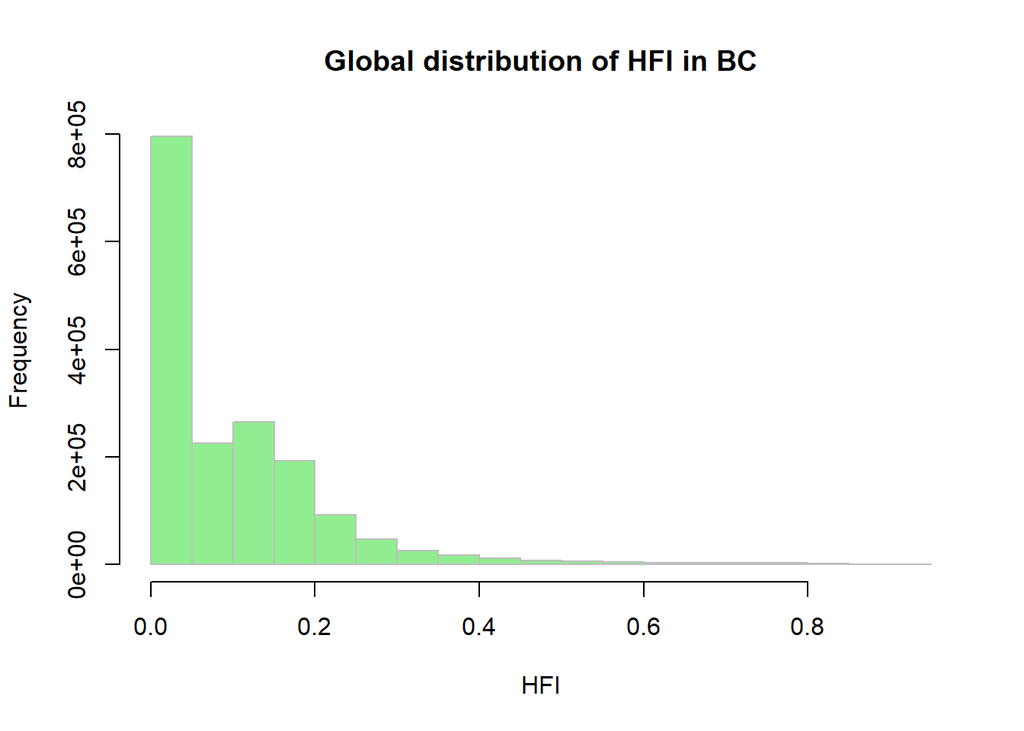

```r
hfi_values <- getValues(hfi_raster)

hist(hfi_values,
     main = "Global distribution of HFI in BC",
     xlab = "HFI",
     col = "lightgreen", border = "grey")
```

### Model

```r
hfi_matrix <- as.matrix(hfi)
media_hfi <- mean(as.vector(hfi_matrix), na.rm = TRUE)
cat("Mean HFI (without NA):", media_hfi, "\n")
```

```
## Mean HFI (without NA): 0.09459461
```

```r
# Impute NA values in HFI using the mean
hfi_clean <- eval.im( ifelse(is.na(hfi), media_hfi, hfi) )

summary(as.vector(as.matrix(hfi_clean)))
```

```
##    Min. 1st Qu.  Median    Mean 3rd Qu.    Max.
## 0.00000 0.09440 0.09459 0.09459 0.09459 0.92381
```

```r
# model
mod_hfi_clean <- ppm(bears_ppp, ~ hfi, covariates = list(hfi = hfi_clean))
mod_hfi_clean
```

```
## Nonstationary Poisson process
## Fitted to point pattern dataset 'bears_ppp'
##
## Log intensity:  ~hfi
##
## Fitted trend coefficients:
## (Intercept)         hfi
##  -20.606402    5.888651
##
##               Estimate       S.E.    CI95.lo    CI95.hi Ztest       Zval
## (Intercept) -20.606402 0.02759958 -20.660496 -20.552308   *** -746.62024
## hfi           5.888651 0.05917443   5.772671   6.004631   ***   99.51343
```

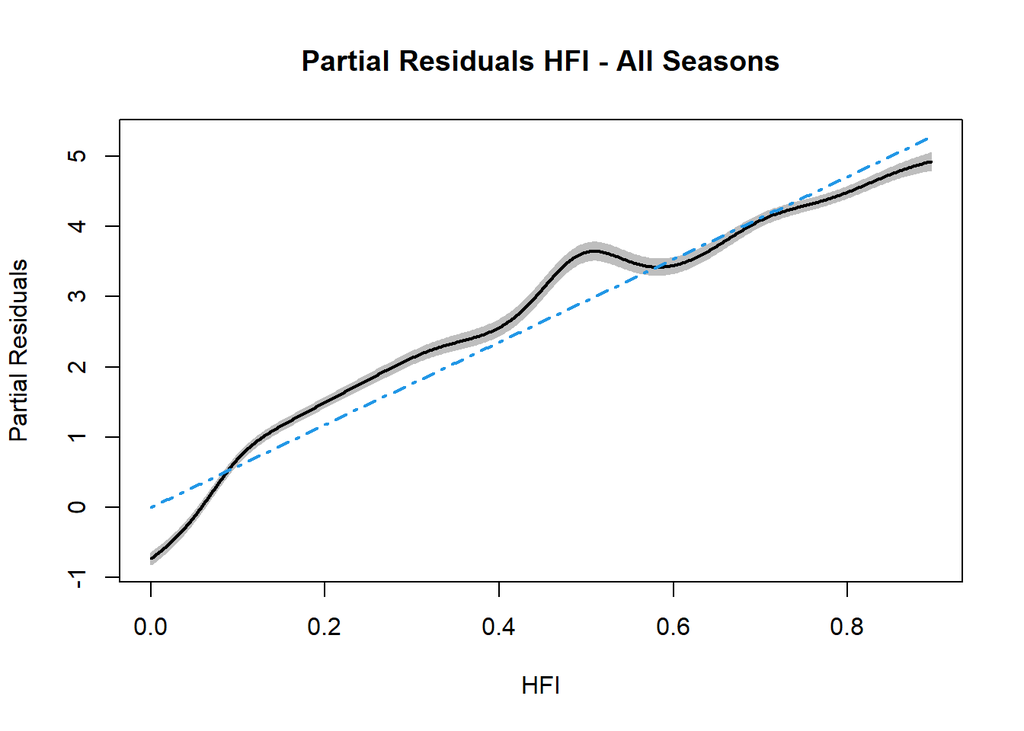

```r
par_res_hfi_all <- parres(mod_hfi_clean, "hfi")

# Plots partial residuals
plot(par_res_hfi_all,
     legend = FALSE,
     lwd    = 2,
     main   = "Partial Residuals HFI - All Seasons",
     xlab   = "HFI",
     ylab   = "Partial Residuals")
```

**Interpretation:** The HFI object was transformed into a spatial raster, where each cell contains a human footprint value. The mean of all valid values was calculated (0.09459), and the NAs were imputed with this mean, resulting in a highly concentrated distribution around that value (median and quartiles practically equal), except for some extreme values reaching up to 0.92381. A point process model (ppm) was fitted to these complete data, yielding an intercept of -20.61 and an HFI coefficient of 5.89, revealing a clearly positive relationship: areas with greater human footprints show a much higher intensity of bear sightings.

The partial residuals analysis illustrates that, although the overall trend is increasing, the association is not perfectly linear. For low HFI values, the linear model tends to overestimate bear presence. In the mid range, the partial residuals exceed the linear prediction, indicating an even higher intensity. and at high values the residual curve returns to coincide with the straight line, showing that the nonlinearity is stronger at intermediate levels and attenuates at the extremes.

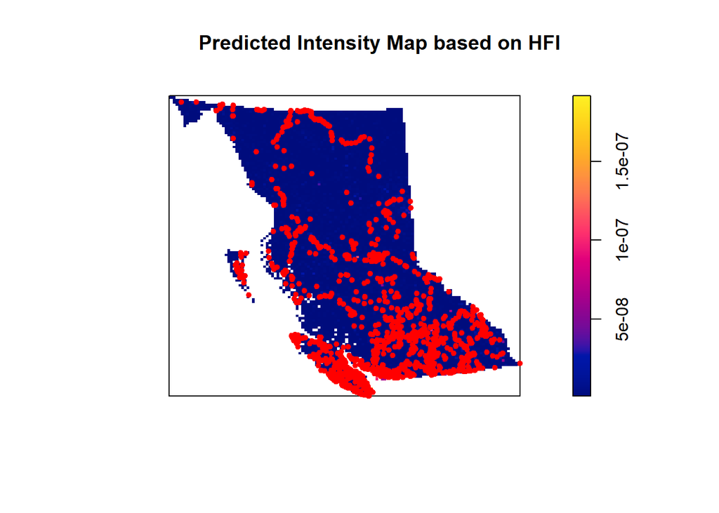

```r
# Predict the intensity in the study region
pred_intensity <- predict(mod_hfi_clean)

# Plot
plot(pred_intensity, main = "Predicted Intensity Map based on HFI")
points(bears_ppp, pch = 20, col = "red")
```

**Interpretation:** The predicted intensity map shows that, based on the human footprint (HFI), most of the study area has very low intensities, indicating few expected events per unit area. Although the model shows a positive relationship between HFI and intensity, most HFI values are low, making the differences subtle. The overlay of actual occurrence points helps verify that, despite the reduced scale, the model captures spatial variation in areas with slight increases in HFI.

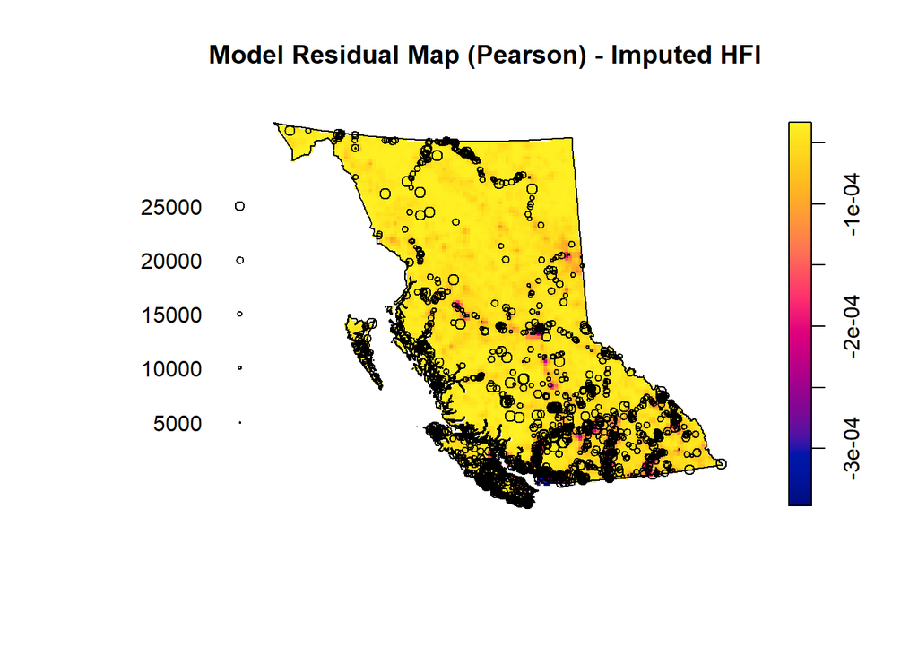

```r
mod_res_clean <- residuals(mod_hfi_clean, type = "pearson")

mod_res_clean$v[!is.finite(mod_res_clean$v)] <- NA

# Residuals
plot(mod_res_clean, main = "Model Residual Map (Pearson) - Imputed HFI", na.col = "transparent")
```

**Interpretation:** The distribution of the residuals does not show large spatial patterns, which would indicate that, although there are specific variations, globally the inhomogeneous Poisson model with HFI imputes a reasonable fit, but there could be specific areas that require complementary analysis or the incorporation of more covariates to improve the fit.

```r
# quad model
mod_hfi_quad <- ppm(bears_ppp,
                    ~ hfi + I(hfi^2),
                    covariates = list(hfi = hfi_clean))

print(mod_hfi_quad)
```

```
## Nonstationary Poisson process
## Fitted to point pattern dataset 'bears_ppp'
##
## Log intensity:  ~hfi + I(hfi^2)
##
## Fitted trend coefficients:
## (Intercept)         hfi    I(hfi^2)
##  -21.200136   11.035131   -6.201408
##
##               Estimate       S.E.    CI95.lo    CI95.hi Ztest       Zval
## (Intercept) -21.200136 0.04486722 -21.288075 -21.112198   *** -472.50838
## hfi          11.035131 0.27261707  10.500812  11.569451   ***   40.47851
## I(hfi^2)     -6.201408 0.31920737  -6.827043  -5.575773   ***  -19.42752
```

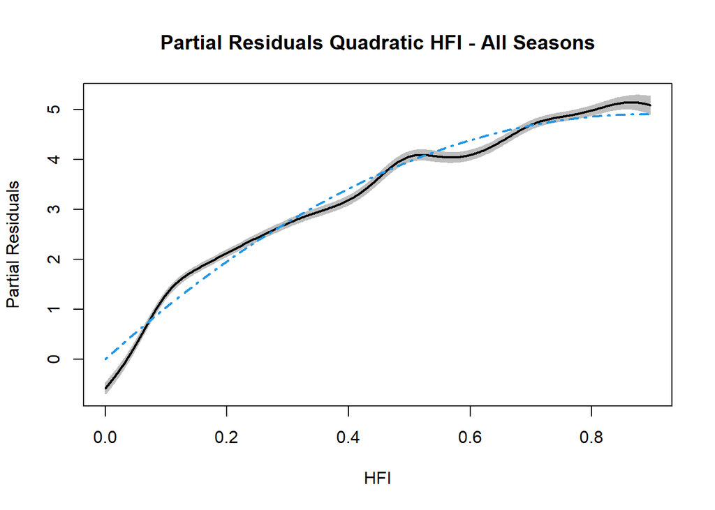

```r
par_res_hfi_quad <- parres(mod_hfi_quad, "hfi")

plot(par_res_hfi_quad,
     legend = FALSE,
     lwd    = 2,
     main   = "Partial Residuals Quadratic HFI - All Seasons",
     xlab   = "HFI",
     ylab   = "Partial Residuals")
```

**Interpretation:** The quadratic model shows a positive linear effect of HFI and a negative quadratic effect, implying that bear occurrence intensity increases with increasing HFI but at a decreasing rate, at very high levels of human footprint the increase is attenuated. The partial residuals plot confirms that this curvilinear shape captures the observed relationship well, the parameterized line (dashed blue) fits the point cloud and the black curve of the partial residuals much better than the simple linear effect, eliminating the small overdetection in the middle range that we saw before and reflecting the moderation of the intensity at high HFI values.

### Stational analysis

```r
# model for each season (individually)
models_seasonal <- list()

for (season in names(ppp_list)) {
  models_seasonal[[season]] <- ppm(ppp_list[[season]], ~ hfi + I(hfi^2), covariates = list(hfi = hfi_clean))
  cat("Model for", season, ":\n")
  print(models_seasonal[[season]])
}
```

```
## Model for winter :
## Nonstationary Poisson process
## Fitted to point pattern dataset 'ppp_list[[season]]'
##
## Log intensity:  ~hfi + I(hfi^2)
##
## Fitted trend coefficients:
## (Intercept)         hfi    I(hfi^2)
##  -25.992080   14.265389   -8.384068
##
##               Estimate      S.E.   CI95.lo    CI95.hi Ztest       Zval
## (Intercept) -25.992080 0.4133031 -26.80214 -25.182021   *** -62.888660
## hfi          14.265389 2.1495753  10.05230  18.478479   ***   6.636376
## I(hfi^2)     -8.384068 2.2731891 -12.83944  -3.928699   ***  -3.688240
## *** Fitting algorithm for 'glm' did not converge ***
## Model for spring :
## Nonstationary Poisson process
## Fitted to point pattern dataset 'ppp_list[[season]]'
##
## Log intensity:  ~hfi + I(hfi^2)
##
## Fitted trend coefficients:
## (Intercept)         hfi    I(hfi^2)
##  -22.792274   12.241461   -8.053626
##
##               Estimate       S.E.    CI95.lo    CI95.hi Ztest       Zval
## (Intercept) -22.792274 0.09718671 -22.982756 -22.601791   *** -234.52049
## hfi          12.241461 0.59045609  11.084189  13.398734   ***   20.73221
## I(hfi^2)     -8.053626 0.70258111  -9.430659  -6.676592   ***  -11.46291
## Model for summer :
## Nonstationary Poisson process
## Fitted to point pattern dataset 'ppp_list[[season]]'
##
## Log intensity:  ~hfi + I(hfi^2)
##
## Fitted trend coefficients:
## (Intercept)         hfi    I(hfi^2)
##  -21.807035   11.351455   -7.106101
##
##               Estimate       S.E.    CI95.lo    CI95.hi Ztest       Zval
## (Intercept) -21.807035 0.06128943 -21.927160 -21.686910   *** -355.80415
## hfi          11.351455 0.38253159  10.601707  12.101203   ***   29.67456
## I(hfi^2)     -7.106101 0.45824425  -8.004243  -6.207958   ***  -15.50723
## Model for autumn :
## Nonstationary Poisson process
## Fitted to point pattern dataset 'ppp_list[[season]]'
##
## Log intensity:  ~hfi + I(hfi^2)
##
## Fitted trend coefficients:
## (Intercept)         hfi    I(hfi^2)
##  -22.729297   10.933311   -6.054719
##
##               Estimate       S.E.    CI95.lo    CI95.hi Ztest        Zval
## (Intercept) -22.729297 0.09524716 -22.915978 -22.542616   *** -238.634899
## hfi          10.933311 0.57068071   9.814797  12.051824   ***   19.158368
## I(hfi^2)     -6.054719 0.64938719  -7.327494  -4.781943   ***   -9.323742
```

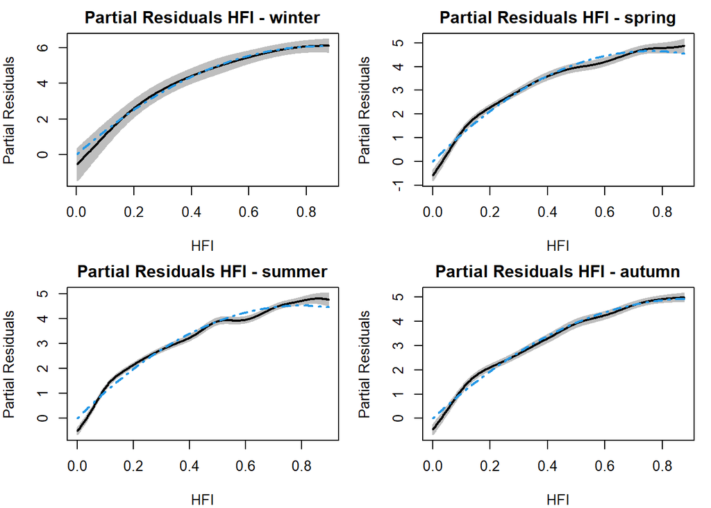

```r
par(mfrow = c(2, 2), mar = c(4, 4, 2, 1))  # 2x2 panel
for (season in names(models_seasonal)) {
  pr <- parres(models_seasonal[[season]], "hfi")
  plot(pr,
       legend = FALSE,
       lwd    = 2,
       main   = paste("Partial Residuals HFI -", season),
       xlab   = "HFI",
       ylab   = "Partial Residuals")
}
```

```r
# Combine the data from each season into a single data frame
bears_all <- do.call(rbind, lapply(names(bears_sf_list), function(season) {
  sf_season <- bears_sf_list[[season]]
  coords <- st_coordinates(sf_season)
  hfi_vals <- extract(hfi_raster, sf_season)
  data.frame(x = coords[, 1], y = coords[, 2],
             hfi_value = hfi_vals, season = season)
}))

# Convert "season" to a factor
bears_all$season <- as.factor(bears_all$season)

# Create a ppp object for the entire dataset using the defined study window.
bears_ppp_all <- ppp(
  x = bears_all$x,
  y = bears_all$y,
  window = window,
  marks = bears_all$season
)
# Check how many points remain in the ppp object
cat("Number of points in bears_ppp_all:", npoints(bears_ppp_all), "\n")
```

```
## Number of points in bears_ppp_all: 3400
```

```r
# Retrieve the marks from the ppp object (these correspond to the points kept after rejection)
current_marks <- marks(bears_ppp_all)

# Convert the marks into a data frame with the correct number of rows
marks(bears_ppp_all) <- data.frame(season = current_marks)

# Fit the combined model including the interaction between HFI and season.
mod_combined <- ppm(bears_ppp_all, ~ hfi * marks,
                    covariates = list(hfi = hfi_clean))
# Display the model summary
mod_combined
```

```
## Nonstationary multitype Poisson process
## Fitted to point pattern dataset 'bears_ppp_all'
##
## Possible marks: 'autumn', 'spring', 'summer' and 'winter'
##
## Log intensity:  ~hfi * marks
##
## Fitted trend coefficients:
##     (Intercept)             hfi     marksspring     markssummer     markswinter
##     -22.2558169       6.4079057       0.2103950       1.0855488      -3.0452231
## hfi:marksspring hfi:markssummer hfi:markswinter
##      -0.6546752      -0.7878781       1.4138929
##
##                    Estimate       S.E.      CI95.lo     CI95.hi Ztest
## (Intercept)     -22.2558169 0.06057996 -22.37455146 -22.1370824   ***
## hfi               6.4079057 0.11995740   6.17279348   6.6430179   ***
## marksspring       0.2103950 0.08333881   0.04705392   0.3737361     *
## markssummer       1.0855488 0.07114357   0.94610998   1.2249876   ***
## markswinter      -3.0452231 0.25479308  -3.54460836  -2.5458378   ***
## hfi:marksspring  -0.6546752 0.17356246  -0.99485135  -0.3144990   ***
## hfi:markssummer  -0.7878781 0.14620642  -1.07443741  -0.5013188   ***
## hfi:markswinter   1.4138929 0.42912943   0.57281473   2.2549712   ***
##                        Zval
## (Intercept)     -367.379207
## hfi               53.418175
## marksspring        2.524574
## markssummer       15.258566
## markswinter      -11.951750
## hfi:marksspring   -3.771986
## hfi:markssummer   -5.388806
## hfi:markswinter    3.294794
## *** Fitting algorithm for 'glm' did not converge ***
```

**Interpretation:**

First, the bear data from each station was combined into a single dataset, generating a point-processing (PPP) object that incorporates seasonality as a marker. Problems were noted during this step, as some points were rejected for being located outside the study window, and duplicates were detected, resulting in 3,400 points for analysis.

The combined model was fitted by including the interaction between HFI and the variable season (with autumn as the reference). This allows both the intercept and slope associated with HFI to vary by season. In autumn, the following relationship is observed:

$$\log(\lambda) = -22.2558 + 6.4079 \times \text{HFI}$$

Meanwhile, in spring and summer, both the intercept and slope are adjusted, resulting in a slightly lower response to the HFI compared to autumn. In winter, although the intercept is lower, the slope increases significantly, implying that intensity responds more sensitively to changes in HFI.

It is important to note that, during the fitting of the combined model, a warning was issued that the fitting algorithm (glm) did not converge, so it is suggested that the parameters be interpreted with caution, especially in winter.

```r
# Each row represents one occurrence, so we assign count = 1 to each one
bears_all$count <- 1

# GAM model with a smooth function for hfi_value and a term for season
gam_model <- gam(count ~ s(hfi_value) + season, data = bears_all, family = poisson())

summary(gam_model)
```

```
##
## Family: poisson
## Link function: log
##
## Formula:
## count ~ s(hfi_value) + season
##
## Parametric coefficients:
##                Estimate Std. Error z value Pr(>|z|)
## (Intercept)   6.729e-17  4.518e-02       0        1
## seasonspring -9.204e-22  6.548e-02       0        1
## seasonsummer -8.307e-22  5.445e-02       0        1
## seasonwinter  4.227e-21  1.543e-01       0        1
##
## Approximate significance of smooth terms:
##              edf Ref.df Chi.sq p-value
## s(hfi_value)   1  1.001      0       1
##
## R-sq.(adj) =    NaN   Deviance explained =  NaN%
## UBRE = -0.99517  Scale est. = 1         n = 2071
```

**Interpretation:** The fitted GAM model, which modeled the occurrence count (with 1 for each point) based on a smooth term for the variable hfi_value and a categorical effect of season, found no evidence of a significant effect for any of the predictors. The parametric coefficients associated with the intercept and seasons presented practically zero values, with relatively large standard errors and p-values of 1, indicating that, in this case, differences between seasons are not detectable.

Similarly, the smooth term for hfi_value had an effective degree of freedom (edf) equal to 1 and a chi-square statistic of 0, suggesting that the smooth function behaves like a straight line without any significant variation. Taken together, these results indicate that, based on this formulation of the GAM model, no significant relationship is observed between human footprint or seasonality with the frequency of bear occurrences in the analyzed dataset.

```r
mod_ppp <- ppm(bears_ppp_all, ~ polynom(hfi, degree = 2) + marks)
mod_ppp
```

```
## Nonstationary multitype Poisson process
## Fitted to point pattern dataset 'bears_ppp_all'
##
## Possible marks: 'autumn', 'spring', 'summer' and 'winter'
##
## Log intensity:  ~hfi + I(hfi^2) + marks
##
## Fitted trend coefficients:
##  (Intercept)          hfi     I(hfi^2)  marksspring  markssummer  markswinter
## -22.80745620  11.76486608  -6.89038945  -0.03203349   0.79211911  -2.39915710
##
##                 Estimate       S.E.     CI95.lo      CI95.hi Ztest         Zval
## (Intercept) -22.80745620 0.05661164 -22.9184130 -22.69649942   *** -402.8757279
## hfi          11.76486608 0.27904318  11.2179515  12.31178066   ***   42.1614539
## I(hfi^2)     -6.89038945 0.32349613  -7.5244302  -6.25634868   ***  -21.2997583
## marksspring  -0.03203349 0.05062724  -0.1312611   0.06719408         -0.6327323
## markssummer   0.79211911 0.04280346   0.7082259   0.87601235   ***   18.5059594
## markswinter  -2.39915710 0.12308502  -2.6403993  -2.15791489   ***  -19.4918686
## Problem:
##  Values of the covariate 'hfi' were NA or undefined at 0.32% (128 out of 39680)
## of the quadrature points
```

**Interpretation:** The fitted model is a nonstationary multitype point process that uses second degree polynomial terms in the HFI variable along with fixed season effects (with autumn as the reference) to model the logarithmic function of bear occurrence intensity, expressed as

$$\log(\lambda) = \beta_0 + \beta_1\,\text{HFI} + \beta_2\,\text{HFI}^2 +
\text{season effects}$$

In addition, seasonal effects have been incorporated that adjust the base intensity additively. Compared to autumn (the reference category), the adjustments are very slight in spring, moderately positive in summer, and negative in winter. This implies that, for the same HFI value, the bear appearance rate may be higher in summer and lower in winter, reflecting the influence of seasonal conditions that add to the nonlinear HFI response.

In summary, the model suggests that the relationship between HFI and bear presence is complex, in areas with slight increases in human activity, bear presence increases, but when the human footprint becomes very high, bear presence decreases, and this dynamic varies seasonally.